# ps05-rmarkdown

# 4 GDP per capita (50pt)

Let’s look at GDP per capita (*GDP_PC*)

1. (8pt) Make a scatterplot of GDP per capita versus life expectancy by country, using data for 1960. Make the point size dependent on the country size, and color those according to the continent. Feel free to adjust the plot in other ways to make it better.  
   Comment what do you see there.

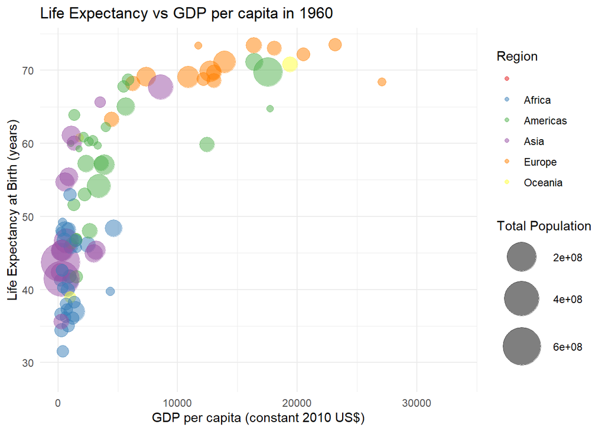

```r
## This plot shows the relationship between life expectancy and GDP per capita in 1960, with each point representing a country. The size of the points represents the total population of each country, and the color represents the continent.We can see that there is a positive relationship between GDP per capita and life expectancy, meaning that as GDP per capita increases, so does life expectancy. This is expected, as wealthier countries typically have better access to healthcare and higher standards of living, which contribute to longer life expectancy.
```

2. (4pt) Make a similar plot, but this time use 2019 data only.

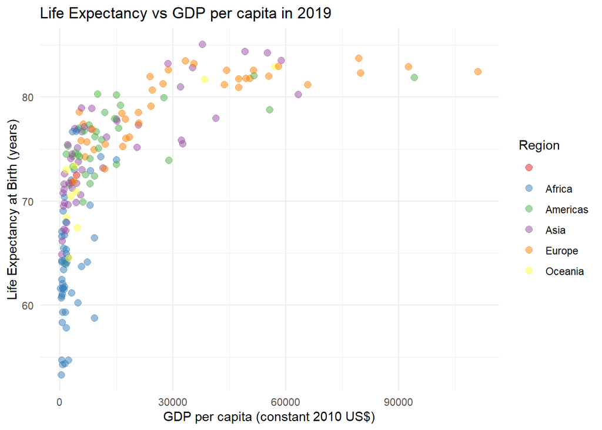

3. (6pt) Compare these two plots and comment what do you see. How has world developed through the last 60 years?

**The two plots show the relationship between GDP per capita and life expectancy for all countries in the world in two different years, 1960 and 2019. Comparing these two plots, we can see that there have been significant changes in the world during the last 60 years.**

**In 1960, we see that most countries were concentrated in the lower left corner of the plot, with low GDP per capita and low life expectancy. However, we can see that the plot is more dispersed in 2019, with a wider range of values for both GDP per capita and life expectancy. Additionally, we can see that the relationship between GDP per capita and life expectancy is stronger in 2019 than it was in 1960, with many countries having higher life expectancy for a given level of GDP per capita.**

4. (6pt) Compute the average life expectancy for each continent in 1960 and 2019. Do the results fit with what do you see on the figures?  
   Note: here as *average*I mean just average over countries, ignore the fact that countries are of different size.

```
## # A tibble: 6 × 2
##   region     avg_life_expectancy
##   <chr>                    <dbl>
## 1 ""                        70.7
## 2 "Africa"                  41.5
## 3 "Americas"                58.6
## 4 "Asia"                    51.6
## 5 "Europe"                  68.3
## 6 "Oceania"                 56.4
```

```
## # A tibble: 6 × 2
##   region     avg_life_expectancy
##   <chr>                    <dbl>
## 1 ""                        77.8
## 2 "Africa"                  64.1
## 3 "Americas"                75.8
## 4 "Asia"                    74.6
## 5 "Europe"                  79.4
## 6 "Oceania"                 73.5
```

5. (8pt) Compute the average LE growth from 1960-2019 across the continents. Show the results in the order of growth. Explain what do you see.  
   Hint: these data (data in long form) is not the simplest to compute growth. But you may want to check out the lag() function. And do not forget to group data by continent when using lag(), otherwise your results will be messed up! See [**https://faculty.washington.edu/otoomet/info201-book/dplyr.html#dplyr-helpers-compute**](https://faculty.washington.edu/otoomet/info201-book/dplyr.html#dplyr-helpers-compute).

```
## # A tibble: 6 × 2
##   region     avg_le_growth
##   <chr>              <dbl>
## 1 ""               0.0551
## 2 "Africa"         0.00746
## 3 "Asia"           0.00650
## 4 "Oceania"        0.00463
## 5 "Americas"       0.00437
## 6 "Europe"         0.00255
```

**The results show that, on average, life expectancy has grown at a higher rate in Africa and Asia compared to other regions. In contrast, Europe has the lowest average annual growth rate of life expectancy..**

6. (6pt) Show the histogram of GDP per capita for years of 1960 and 2019. Try to put both histograms on the same graph, see how well you can do it!

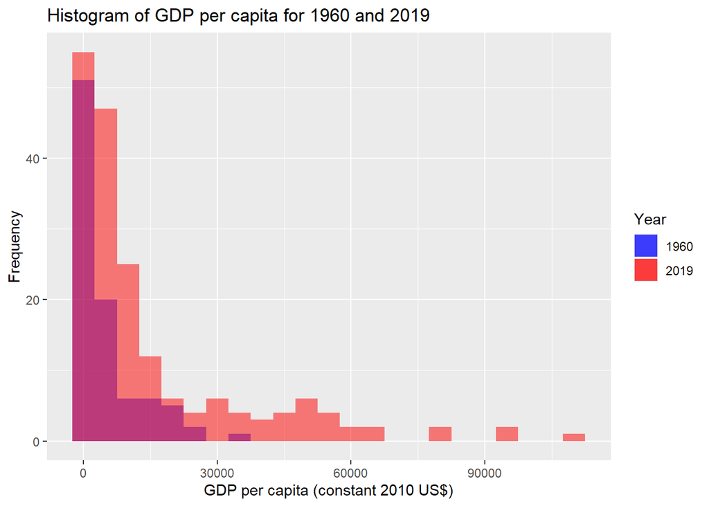

7. (6pt) What was the ranking of US in terms of life expectancy in 1960 and in 2019? (When counting from top.)  
   Hint: check out the function rank()!  
   Hint2: 17 for 1960.

```
## [1] "Ranking of the US in terms of life expectancy in 1960: 18"
```

```
## [1] "Ranking of the US in terms of life expectancy in 2019: 47"
```

8. (6pt) If you did this correctly, then you noticed that US ranking has been falling quite a bit. But we also have more countries in 2019–what about the relative rank divided by the corresponding number of countries that have LE data in the corresponding year?  
   Hint: 0.0904 for 1960.

```
## [1] "Relative rank of the US in terms of life expectancy in 1960: 0.0833"
```

```
## [1] "Relative rank of the US in terms of life expectancy in 2019: 0.2166"
```

Finally tell us how many hours did you spend on this PS.

**Spent five hours on PS**